# Befolkningsutvecklingen i Borlänge

Befolkningsutvecklingen i Borlänge  
- en kort analys

Rapporten är skapad av Samhällsanalys, Region Dalarna  
Senast uppdaterad: 2024-10-03

# Sammanfattning

Syftet med den här korta analysen är att undersöka Borlänges befolkningsutveckling. Ett antal viktiga slutsatser sammanfattas här:

- I Borlänge minskade folkmängden tydligt år 2023, vilket berodde på att säväl födelsenettot som flyttnettot var negativt.
- Det föddes klart färre barn i Borlänge år 2023, jämfört med åren innan. Detta är i linje med en större trend i samhället, då barnafödandet per kvinna i Sverige 2023 var det lägsta som har uppmätts.
- Det utrikes flyttnettot till Borlänge var negativt under 2023. Detta är i linje med en stramare nationell migrationspolitik, men kan även förklaras med att Skatteverket under 2023 inledde en avregistrering av invandrade som inte längre bedömdes bo i Sverige.
- Det inrikes flyttnettot till Borlänge var negativt under 2023 och dessutom lägre jämfört med året innan.

För mer info om statistiken, klicka på rutan nedan:

**Mer information om statistiken**

I folkmängden som SCB publicerar ingår personer som är folkbokförda i landet. För att den som flyttar till Sverige ska bli folkbokförd ska personen ha för avsikt och rätt att stanna i Sverige i minst ett år. För personer som inte är medborgare i ett EU-land innebär det att det krävs ett uppehållstillstånd som gäller minst 12 månader för att bli folkbokförd. Till följd av Rysslands invasion av Ukraina den 24 februari 2022 har Europeiska unionen (EU) beslutat att aktivera massflyktsdirektivet, vilket innebär att personer från Ukraina utan individuell prövning ska erbjudas tidsbegränsat uppehålls- och arbetstillstånd inom EU. Personer som får uppehållstillstånd enligt massflyktsdirektivet ska i regel inte bli folkbokförda och ingå i den officiella befolkningsstatistiken. Läs mer [här](https://www.scb.se/hitta-statistik/statistik-efter-amne/befolkning/befolkningens-sammansattning/befolkningsstatistik/produktrelaterat/Fordjupad-information/statistik-om-invandring---fragor-och-svar/).

Under 2023 inledde Skatteverket ett arbete med att granska registret över folkbokförda. Det förde med sig att SCB avregistrerade flera tusen folkbokförda personer som visade sig inte längre bo i Sverige. I folkbokföringen har dessa registrerats som utvandrade till okänt utvandringsland. Läs mer [här](https://www.scb.se/pressmeddelande/sverige-gar-mot-lagsta-befolkningsokningen-pa-manga-ar/). I Borlänge avregistrerades 88 personer under 2023.

All data som används i rapporten är offentlig och finns under kategorin befolkning i SCB:s [Statistikdatabas](https://www.statistikdatabasen.scb.se/pxweb/sv/ssd/). Där finns även data för exempelvis befolkningsutvecklingen under 2024 på månadsbasis, något som inte behandlas i denna rapport.

# 1 Hur har befolkningen förändrats?

I Borlänge har befolkningen ökat på lång sikt, från ca 42 800 invånare år 1968 till nästan 51 700 invånare år 2023.

Befolkningsutvecklingen i Borlänge tenderar att följa vissa cykler, med tydliga nedgångar under det tidiga 1980-talet och slutet av 1990-talet. Eftersom kommunen traditionellt haft en stark tillverkningsindustri är en möjlig förklaringar till detta ekonomiska kriser som drabbat industrin. Under 2000-talet har kommunens folkmängd ökat tydligt, vilket i första hand kan förklaras med en hög invandring (mer om det nedan). På senare år har trenden dock varit negativ och under 2023 minskade folkmängden med 443 personer, vilket är den största minskningen sedan åtminstone slutet på 1960-talet.

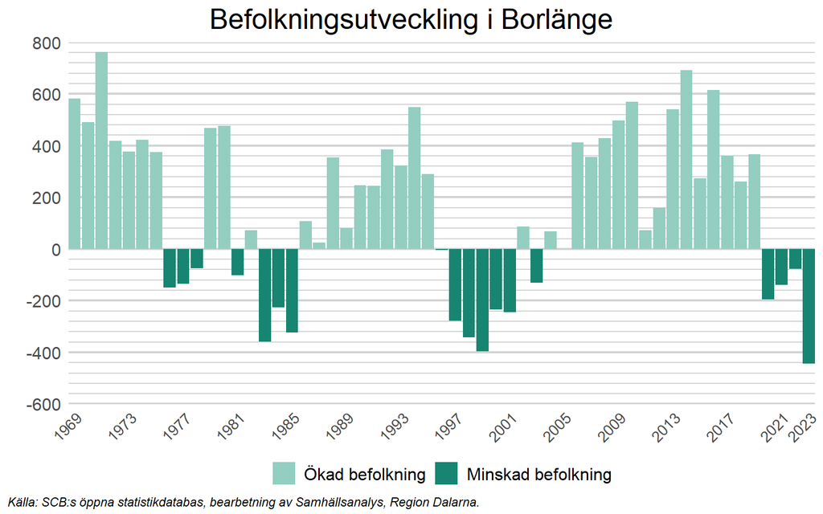

I fortsättningen av denna korta analys delas befolkningsutveckling upp i dess komponenter, födelsenetto, dvs. nettot av födda och döda, och flyttnetto, dvs. nettot av inrikes och utrikes flyttar.

# 2 Födelsenetto

Trots att folkmängden i Borlänge idag är betydligt större än den var på exempelvis 1990-talet, dör ungefär lika många personer idag som då varje år i kommunen. Denna utveckling härrör sannolikt till utveckling inom det medicinska området. Befolkningens medelålder ökar över tid och har gjort så länge.

När gäller antalet födslar är den långsiktiga trenden negativ, det föddes fler barn i Borlänge på slutet av 1960-talet än det gör idag (trots att klart färre då bodde i kommunen). Under såväl flera år i början av 1990-talet som vissa år på slutet av 2010-talet ökade dock antalet födslar i kommunen och var betydligt högre än på 1960-talet. På senare år har trenden dock varit negativ. År 2023 föddes blott 464 barn, vilket är den lägsta siffran sedan början av 2000-talet.

Under stora delar av 2000-talet var nettot mellan födda och döda, se de svarta linjerna i diagrammet nedan, positivt i Borlänge. På senare år har dock nettot tydligt minskat och var år 2023 negativt för första gången sedan början av 2000-talet (-36 personer).

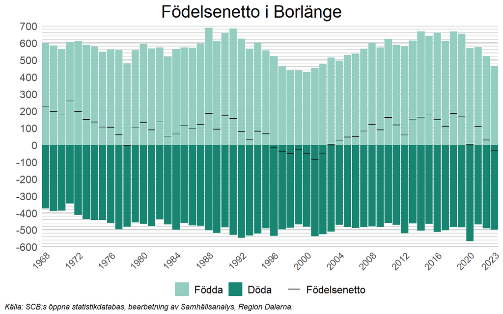

# 3 Flyttnetto

Den andra komponenten som styr befolkningsutvecklingen är det så kallade flyttnettot. Detta kan i sin tur delas upp i två komponenter, inrikes och utrikes flyttar. I det här avsnittet är fokus först på flyttnettot, innan de två komponenterna undersöks.

Antalet personer som flyttar till och från Borlänge har varierat relativt mycket över tid, med omväxlande perioder av positivt och negativt flyttnetto. Under åren efter finanskrisen i början på 1990-talet flyttade många från kommunen, men under stora delar av 2000-talet var flyttnettot istället positivt. Detta hänger samman med att invandringen då var stor. På senare år har flyttnettot återigen varit negativt. År 2023 minskade befolkningen med 423 personer till följd av ett negativt flyttnetto, den största minskningen sedan åtminstone 1997.

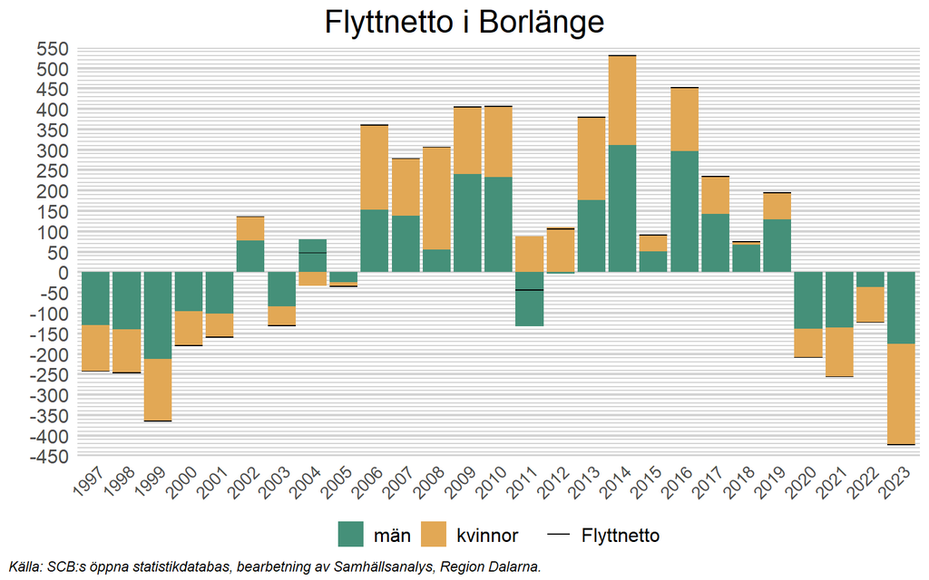

## 3.1 Utrikes flyttnetto

Som berördes i föregående avsnitt, flyttade många till Borlänge under såväl åren runt flyktingkrisen (2015-2016) som under en period mellan 2005 och 2010. Detta beror på att invandringen då var stor, vilket syns i diagrammet nedan. Längre tillbaka var invandringen ofta låg eller till och med negativ under vissa år. På senare år har dock invandringen minskat tydligt, vilket sannolikt hör samman med en stramare nationell migrationspolitik.

År 2023 var det utrikes flyttnettot till kommunen negativt (-140 personer). Detta kan delvis förklaras av den avregistrering av utvandrade som Skattemyndigheten påbörjade under 2023 (se informationsrutan under avsnittet introduktion ovan), men en annan viktig anledningen är som sagt en stramare nationell migrationspolitik.

Generellt invandrar ungefär lika många kvinnor och män till Borlänge.

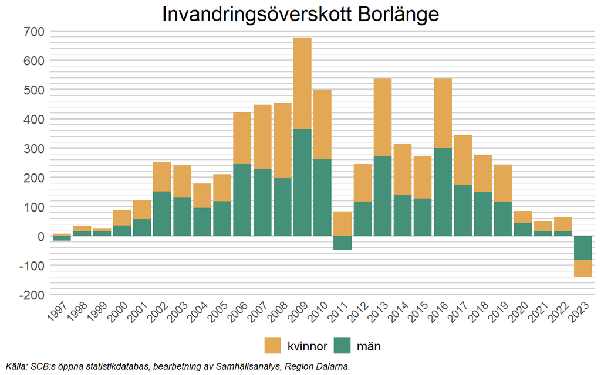

## 3.2 Inrikes flyttnetto

Även det inrikes flyttnettot till Borlänges varierar relativt mycket mellan åren, men är i praktiken alltid negativt. År 2023 flyttade 283 personer netto från kommunen inrikes, vilket är fler än året innan men ungefär i linje med de senaste årens netto.

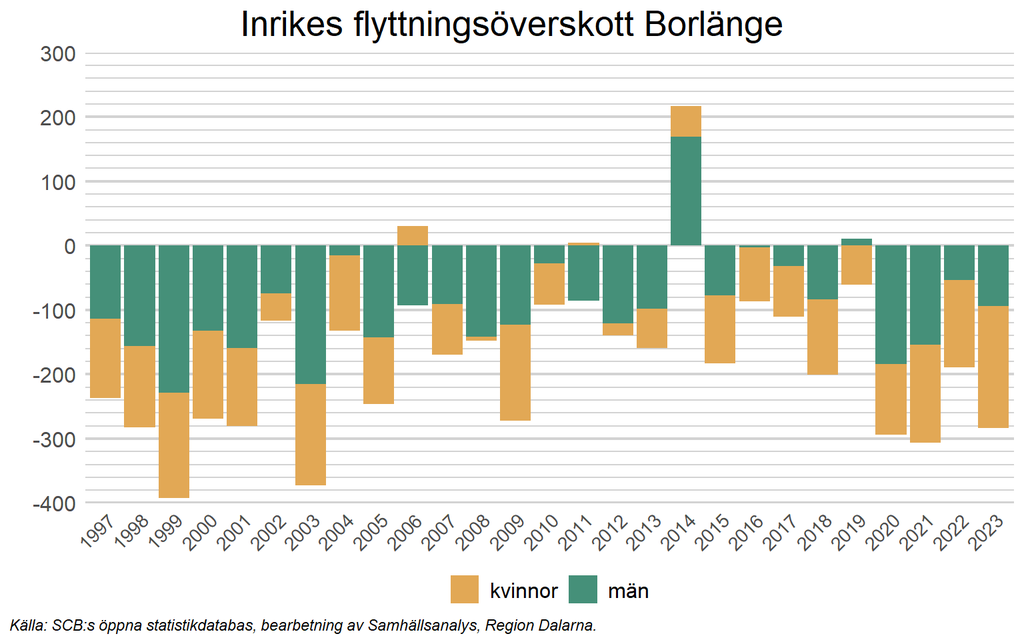

För att bättre förstå vilka som flyttar till och från kommunen inrikes, delas de som flyttar härnäst upp efter ålder. Normalt är personer mest benägna att flytta till en annan ort när de är i 20-års åldern, innan flyttandet gradvis avtar.

### 3.2.1 Uppdelat på ålder

Ett tydligt mönster på senare år är att det i första hand är personer under 40 år som lämnar Borlänge för andra delar av Sverige, medan flyttnetto är mer otydligt i övriga åldersgrupper .

Bland de åldersgrupper som redovisas i diagrammet nedan skedde den största utflyttningen år 2023 i gruppen som är 20-29 år. I denna grupp, tillsammans med de som är under 20 år, var antalet uflyttare 206 fler än antalet inflyttare.

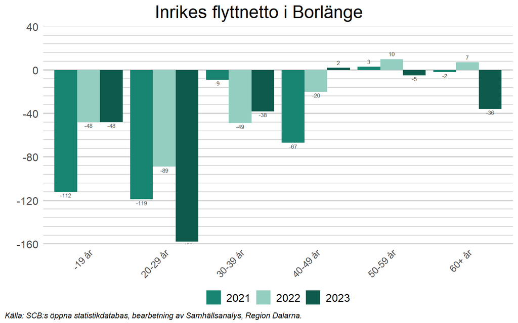

Om fokus enbart läggs på åldersgruppen 20-29 år, blir det tydligt att det under de allra flesta år flyttar fler unga vuxna från än till kommunen inrikes. Historiskt varierar det inrikes flyttnettot i åldersgruppen mellan åren, vilket exempelvis kan bero på att olika årskullar av barn är olika stora. Under 2023 flyttade 158 personer netto från kommunen inrikes, vilket är den största utflyttningen i åldersgruppen sedan 2009.

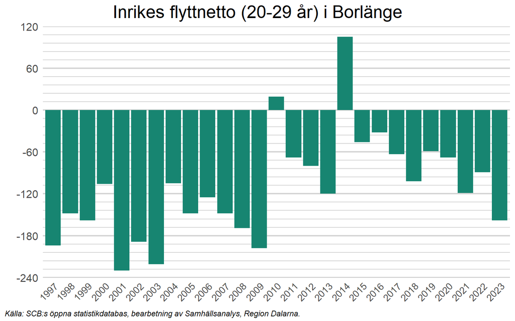

### 3.2.2 Uppdelat på bakgrund

För att ytterligare förtydliga vilka som flyttar till och från Borlänge inrikes, delas de i detta avsnitt upp efter sin bakgrund, inrikes eller utrikes födda.

För såväl inrikes som utrikes födda varierar det inrikes flyttnettot relativt mycket mellan åren i Borlänge, men under en majoritet av åren är det negativt. För utrikes födda är undantaget år 2014 och något år därefter, när många flyttade till kommunen. Bland de som är födda i Sverige är det inrikes flyttnettot alltid negativt

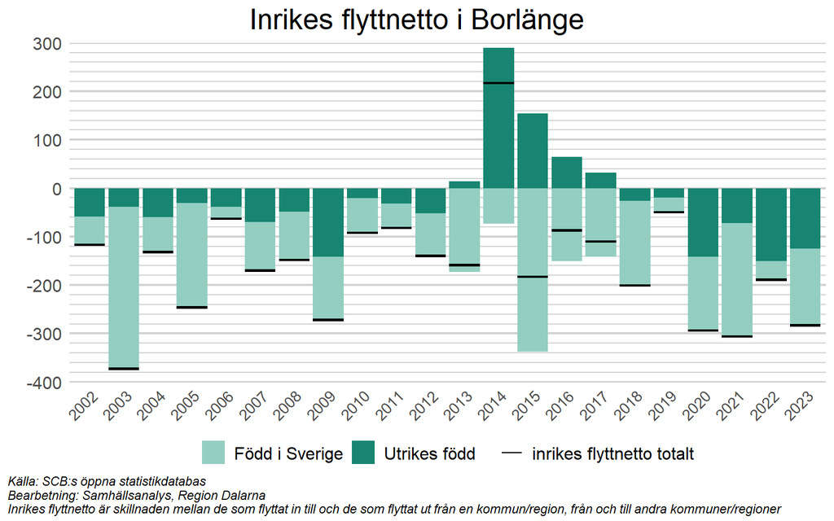

I nästa avsnitt är fokus istället på framtiden. Hur kommer Borlänges folkmängd att utvecklas fram till 2033?

# 4 Vad händer i framtiden?

För en djupare förståelse runt hur SCB gör befolkningsprognoser, se motsvarande avsnitt i rapporten för hela Dalarnas län. Det viktigaste att ha i åtanke är att ingen hänsyn tas i prognoserna till planerat bostadsbyggande, företagsetableringar eller andra framtida mål och förutsättningar som kommunerna har i sina planer.

I diagrammet visas befolkningsutvecklingen i Borlänge fram till 2033 enligt SCB:s senaste prognos (juni 2024), uppdelat på åldersgrupper. Ett par tydliga trender kan utläsas i diagrammet:

- Borlänges befolkning prognostiseras att minska med närmare 1 700 personer fram till 2033, vilket är en tydlig förändring jämfört med föregående prognos. I den prognosen, som släpptes 2022, prognostiserades istället en ökning på ungefär 670 personer fram till 2033, jämfört med 2021 (se [SCB](https://www.statistikdatabasen.scb.se/pxweb/sv/ssd/START__BE__BE0401__BE0401B/BefProgRegFakN22/table/tableViewLayout1/)).
- Den största minskningen sker bland barn och unga, 0-19 år, som prognostiseras minska med ungefär 1 800 personer fram till 2033.
- I åldergruppen 80+ förväntas befolkning istället att öka med ungefär 1 000 personer fram till 2033. Detta hänger sannolikt samman med att den förväntade livslängden fortsätter öka och att den stora gruppen “baby-boomers” börjar komma upp i 80-års åldern.
- Även i den åldersgrupp som brukar benämnas arbetsför ålder, 20-64 år, prognostiseras en minskning av folkmängden, med ungefär 900 personer.

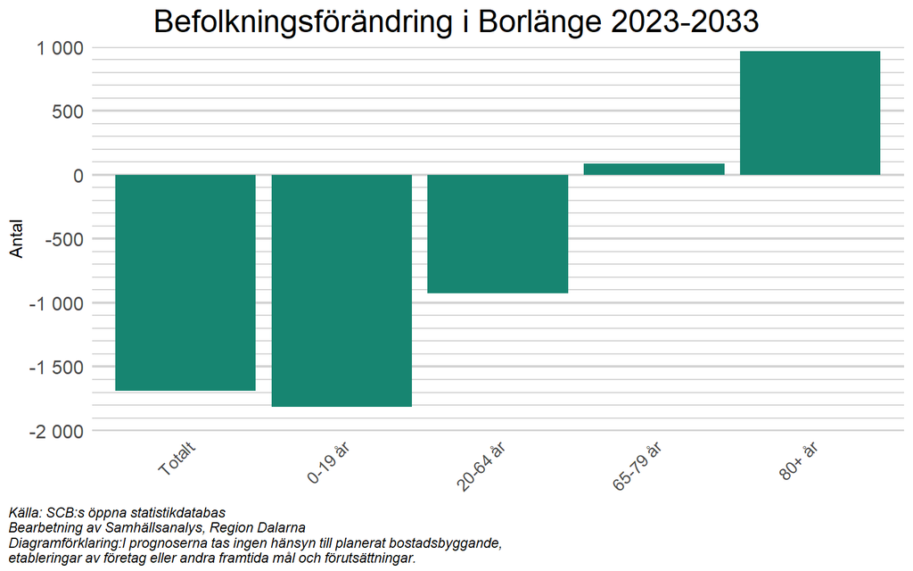